# IODS course project

```r
#Let's see the summary
summary(model)
```

```
##
## Call:
## lm(formula = points ~ attitude + stra + deep, data = students2014)
##
## Residuals:
##      Min       1Q   Median       3Q      Max
## -17.5239  -3.4276   0.5474   3.8220  11.5112
##
## Coefficients:
##             Estimate Std. Error t value Pr(>|t|)
## (Intercept)  11.3915     3.4077   3.343  0.00103 **
## attitude      3.5254     0.5683   6.203 4.44e-09 ***
## stra          0.9621     0.5367   1.793  0.07489 .
## deep         -0.7492     0.7507  -0.998  0.31974
## ---
## Signif. codes:  0 '***' 0.001 '**' 0.01 '*' 0.05 '.' 0.1 ' ' 1
##
## Residual standard error: 5.289 on 162 degrees of freedom
## Multiple R-squared:  0.2097, Adjusted R-squared:  0.195
## F-statistic: 14.33 on 3 and 162 DF,  p-value: 2.521e-08
```

```r
# Print coefficients and significance
coefs <- summary(model)$coefficients[, c("Estimate", "Pr(>|t|)")]
print(coefs)
```

```
##               Estimate     Pr(>|t|)
## (Intercept) 11.3914511 1.030072e-03
## attitude     3.5253519 4.441409e-09
## stra         0.9620827 7.489119e-02
## deep        -0.7491996 3.197410e-01
```

So here we see that for each unit of increase in the variables etimated value of increase is predicted for the points. For p value to mean there is a statistical significance it should be <0.05. Knowing all this it seems attitude overall is the only statistically significant variable for the exam points. This means we only keep attitude as the assignment asks us to remove the variables with no significance.

```r
model2 <- lm(points ~ attitude, data = students2014)

summary(model2)
```

```
##
## Call:
## lm(formula = points ~ attitude, data = students2014)
##
## Residuals:
##      Min       1Q   Median       3Q      Max
## -16.9763  -3.2119   0.4339   4.1534  10.6645
##
## Coefficients:
##             Estimate Std. Error t value Pr(>|t|)
## (Intercept)  11.6372     1.8303   6.358 1.95e-09 ***
## attitude      3.5255     0.5674   6.214 4.12e-09 ***
## ---
## Signif. codes:  0 '***' 0.001 '**' 0.01 '*' 0.05 '.' 0.1 ' ' 1
##
## Residual standard error: 5.32 on 164 degrees of freedom
## Multiple R-squared:  0.1906, Adjusted R-squared:  0.1856
## F-statistic: 38.61 on 1 and 164 DF,  p-value: 4.119e-09
```

Here again we see for both intercept and the attitude p values are statistically significant. Multiple R-squared (0.1906) means that this regression model with the attitude explains about 19.06% of the variability in points. Adjusted R-squared accounts for the number of predictors and is slightly lower. Overall, with the positive coefficient values as well, this model suggests that the attitude is a significant predictor of the exam points.

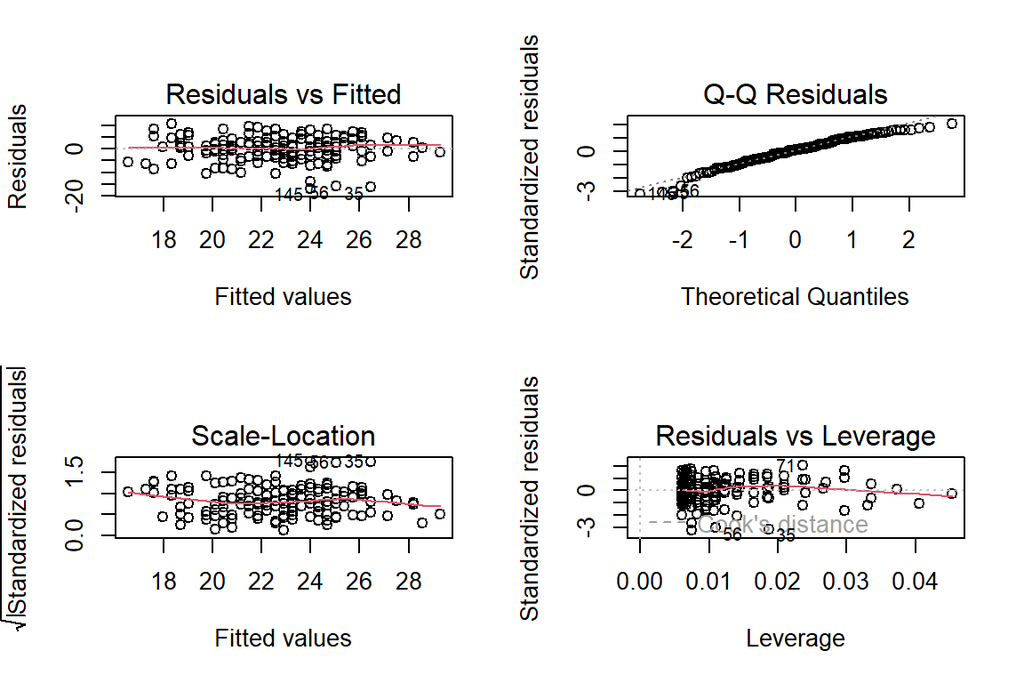

```r
par(mfrow = c(2,2))
plot(model2)
```

Residual vs. Fitted plot line is close/parallel to the horizontal 0 meaning there is no overall pattern emerging here.

Scale-location plot checks for homoscedasticity which means the spread of residuals is constant across all levels of the independent variable.In this case distribution of residuals seem like randomly scattered across the horizontal line which may suggest homoscedasticity.

Residual vs leverage plot helps us find the influential observations/ outliers that may have impact on regression results. In this cas, there are a few points distant from the centre such as the marked 71 with very high residual and, 56 a nd 35 quite low.

```r
# Check student no 71
students2014$points[71]
```

```
## [1] 29
```

```r
students2014$attitude[71]
```

```
## [1] 1.9
```

```r
# Check student no 35
students2014$points[35]
```

```
## [1] 10
```

```r
students2014$attitude[35]
```

```
## [1] 4.2
```

Student number 71 had very high score but low attitude and vice versa for the student number 35 for example, making them both outliers in this model.